# Analyzing DDOT projects

Pete Rodrigue & Spencer Ainsworth

2026-07-15

This document looks at a bunch of DDOT data that’s super cool but a little buried on their website. We’ll do 3 things:

- DDOT conducts evaluations of their bus priority and bike infrastructure projects. We’ll look at those evaluations and try to replicate them.
- We’ll also try to scale those evaluations to a bunch of other project that aren’t on DDOT’s evaluations page, using the same crash data.
- Finally, we’ll look at some neat data DDOT staff collect by standing on streets and watching people bike by.

To view the code in this document, click the “show” buttons on the right. Some of this analysis also uses supporting functions I put in a separate set of files; you can find all of the code here: https://github.com/pete-rodrigue/ddot-project-evals

```r
knitr::opts_chunk$set(echo = TRUE, fig.width = 8,
                      message=F, warning=F,
                      root.dir = "C:/Users/edwar/Documents/GitHub/ddot-project-evals")

setwd("C:/Users/edwar/Documents/GitHub/ddot-project-evals")
source("load_data.R")
source("make_plots.R")

# Libraries we need:
library(readr)
library(ggplot2)
library(dplyr)
library(stringr)
library(purrr)
library(broom)
library(sf)
library(leaflet)
library(tidyr)
library(tidyverse)
library(plotly)
library(zoo)
```

```r
# google sheet w/ the data:
url <- "https://docs.google.com/spreadsheets/d/e/2PACX-1vQtDsTt9VVyn-wptsMT6vxtCM2J1dPYWji90OOWj1v4c4pPz6Kwa6mQtOk096EU3npvJ9g4fcjnwLpp/pub?gid=1445637369&single=true&output=csv"

# load the data from the google sheet:
df <-
  read_csv(url, show_col_types = F) %>%
  filter(`Project name` != "15 St NW") %>%
  mutate(
    `Project short name` =
      case_when(
          `Project name` == "16th Street NW Bus Priority Project" ~ "16 ST NW",
          `Project name` == "9th Street NW Protected Bike Lane" ~ "9 ST NW",
          `Project name` == "G Street NW Protected Bike Lane" ~ "G ST NW",
          `Project name` == "Minnesota Avenue SE Bus Priority Project" ~ "MN AVE SE",
          `Project name` == "Pennsylvania Avenue SE Bus Priority Project" ~ "PA AVE NW",
          `Project name` == "Virginia Avenue NW Protected Bike Lane" ~ "VA AVE NW",
          .default = NA
        )
  )
```

## DDOT’s bus and bike project evaluations

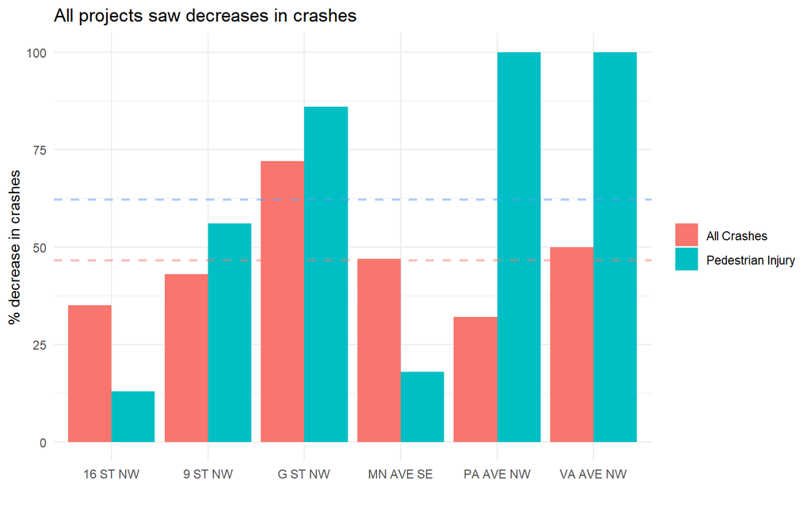

```r
# to_plot <-
  df %>%
  filter(Outcome %in% c("Injury Crashes", "All Crashes", "Pedestrian Injury")) %>%
  mutate(Change = Change*-1) %>%
  ggplot() +
  geom_bar(aes(x=`Project short name`, y=Change, fill=Outcome), stat="identity", position="dodge") +
  labs(y="% decrease in crashes", x="") +
  ggtitle("All projects saw decreases in crashes") +
  geom_hline(aes(yintercept=mean(Change[Outcome == "All Crashes"], na.rm=T)),
             color="#F8766D", linetype="dashed", linewidth=.8, alpha=.5) +
  geom_hline(aes(yintercept=mean(Change[Outcome == "Injury Crashes"], na.rm=T)),
             color="#00BA38", linetype="dashed", linewidth=.8, alpha=.5) +
  geom_hline(aes(yintercept=mean(Change[Outcome == "Pedestrian Injury"], na.rm=T)),
             color="#619CFF", linetype="dashed", linewidth=.8, alpha=.5) +
  theme_minimal() +
  theme(legend.title = element_blank())
```

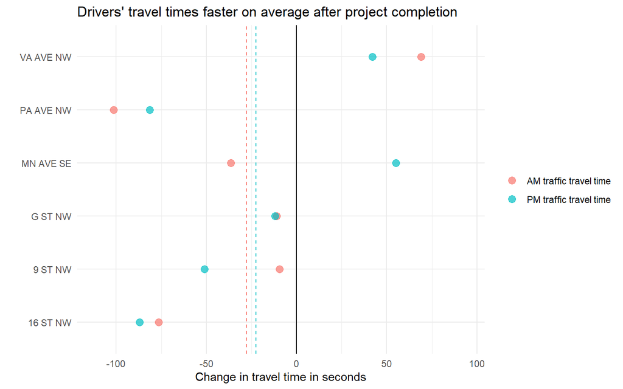

```r
to_plot <-
  df %>%
  filter(str_detect(Outcome, "Private motor vehicle")) %>%
  group_by(`Project short name`, Outcome) %>%
  summarize(change = mean(Change, na.rm=T)) %>%
  ungroup() %>%
  mutate(Outcome = ifelse(Outcome == "Private motor vehicle AM peak travel time (seconds)",
                          "AM traffic travel time",
                          "PM traffic travel time"))

ggplot(to_plot) +
  geom_point(
    aes(x=change, color=Outcome, y=`Project short name`), size=3, alpha=.7
  ) +
  geom_vline(aes(xintercept=0), color="black") +
  geom_vline(aes(xintercept=mean(change[Outcome == "AM traffic travel time"], na.rm=T)), color="#F8766D", linetype="dashed") +
  geom_vline(aes(xintercept=mean(change[Outcome == "PM traffic travel time"], na.rm=T)), color="#00BFC4", linetype="dashed") +
  labs(x="Change in travel time in seconds", y="") +
  theme_minimal() +
  xlim(c(min(to_plot$change)-10, max(to_plot$change)+25)) +
  theme(legend.title = element_blank()) +
  ggtitle("Drivers' travel times faster on average after project completion")
```

```r
rm(to_plot); rm(url)
```

```r
outcome_vars <-
  c("All Crashes", "Vehicle Crashes", "Bike Crashes", "Pedestrian Crashes",
    "Injury Crashes", "Serious Injury Crashes", "Driver Injury", "Bicyclist Injury", "Pedestrian Injury",
    "Driver Serious Injury", "Bicyclist Serious Injury", "Pedestrian Serious Injury",
    "Fatal Crashes")


# load crash data:
cd <- load_crash_data()
# crash_details <- read_csv("data/Crash_Details_Table.csv", show_col_types = F)
# load project shapefiles:
ddot_projs <-
  st_read("data/ddot-evaluated-projects.geojson", quiet=T) |>
  st_transform(4326) |>
  filter(project_name != "Minnesota Ave Bike Lane Project")

get_crashes_in_corridors <- function(line_sf, crashes_sf, buffer_in_meters) {
  mybuffer <-
    line_sf |>
    st_transform(6487) |>               # EPSG:6487 — NAD83 / Maryland (metres)
    st_buffer(dist = buffer_in_meters,  # X m buffer
              endCapStyle = "FLAT"
              ) |>
    st_transform(st_crs(ddot_projs))    # reproject back to match cd's CRS

  crashes_near_projects <- st_join(crashes_sf, mybuffer, join = st_within, left = FALSE)

  crashes_near_projects
}

group_corridor_crashes_by_month <- function(df, group_by_vars = NA, outcome_vars) {
    df                                      |>
    st_drop_geometry()                      |>
    group_by(across(all_of(group_by_vars))) |>
    summarize(
      `All Crashes` = n(),
      across(all_of(outcome_vars), \(x) sum(x, na.rm = TRUE)),
      .groups = "drop_last"
      )                                     |>
    ungroup()
}

crashes_near_projects <- get_crashes_in_corridors(line_sf = ddot_projs, crashes_sf = cd, buffer_in_meters = 4)

cd_in_projs_summed <-
  group_corridor_crashes_by_month(df = crashes_near_projects,
                                  group_by_vars = c("project_name", "month", "year", "date"),
                                  outcome_vars = outcome_vars)
```

```r
# plot the projects:
source("make_plots.R")
# create a list that has the project names and pre & post dates:
proj_dates <-
  list(
     "Minnesota Avenue SE Bus Priority Project" =
       list(
        period_1         = list(label = "Pre",  start = "2017-02-01", end = "2020-01-31"),
        period_2         = list(label = "Post", start = "2023-11-01", end = "2024-10-31")
       ),
     "Pennsylvania Avenue SE Bus Priority Project" =
       list(
        period_1         = list(label = "Pre",  start = "2018-06-01", end = "2022-05-31"),
        period_2         = list(label = "Post", start = "2024-05-01", end = "2024-08-31")
       ),
     "9th Street NW Protected Bike Lane" =
       list(
        period_1         = list(label = "Pre",  start = "2016-02-01", end = "2020-01-31"),
        period_2         = list(label = "Post", start = "2023-10-01", end = "2024-09-30")
       ),
     "Virginia Avenue NW Protected Bike Lane" =
       list(
        period_1         = list(label = "Pre",  start = "2018-04-01", end = "2022-03-31"),
        period_2         = list(label = "Post", start = "2023-04-01", end = "2024-03-31")
       ),
     "21st Street NW Protected Bike Lane" =
       list(
        period_1         = list(label = "Pre",  start = "2017-02-01", end = "2020-01-31"),
        period_2         = list(label = "Post", start = "2023-11-01", end = "2024-10-31")
       ),
     "16th Street NW Bus Priority Project" =
       list(
        period_1         = list(label = "Pre",  start = "2017-02-01", end = "2020-01-31"),
        period_2         = list(label = "Post", start = "2023-01-01", end = "2024-12-31")
       ),
     "G Street NW Protected Bike Lane" =
       list(
        period_1         = list(label = "Pre",  start = "2018-03-01", end = "2020-02-29"),
        period_2         = list(label = "Post", start = "2021-03-01", end = "2024-02-29")
       )
  )
```

Below is a quick look at all of the crashes in these project corridors. Note that DDOT seems to map all of these crashes to the roadway center line. I just drew the corridor center lines by hand in Felt GIS, and then made a little buffer aroud each center line in R. I assigned all of the crashes that fell within that buffer to the corridor.

```r
plot_leaflet(
  lines_sf = ddot_projs,
  # polygons_sf = ddot_projs_buf,
  line_labels = c("felt.feature", "project_name"),
  points_sf = crashes_near_projects
  )
```

[interactive chart not shown]

## Replicating DDOT project evaluations

Below, we try to replicate those results. The data actually agrees pretty well, given I only had DDOT’s PDF that briefly describes their methodology, not their actual code or a detailed how-to. This suggests the results are relatively robust to little choices about how to do the analysis.

Crashes go down, sometimes by quite a lot, after these projects get installed.

```r
eval_summary <- data.frame("Project" = NA, "Source" = NA, "Outcome" = NA, "% change" = NA)
eval_objs    <- list()
for (proj in unique(cd_in_projs_summed$project_name)) {

  if(proj %in% c("15th St NW/SW Protected Bike Lane", "21st Street NW Protected Bike Lane")) {next}


  periods <- proj_dates[[proj]]
  p1      <- periods$period_1
  p2      <- periods$period_2

  rvs <- plot_crashes_over_time(
    data             = filter(cd_in_projs_summed, year >= 2016 &
                              project_name == proj),
    smoothing_factor = 4,
    period_1         = p1,
    period_2         = p2,
    title            = proj
  )

  plot_table <-
    rvs[[3]] %>%
      dplyr::left_join(
        select(df, `Project name`, Outcome, Change) %>%
          filter(`Project name` == proj) %>%
          mutate(Outcome = if_else(Outcome == "Any Injury", "Injury Crashes", Outcome)),
        by=c("series"="Outcome")) %>%
      rename(pct_change_ddot = Change) %>%
      select(-`Project name`)

  eval_objs <- c(eval_objs, list(list(proj, rvs[[1]], plot_table)))

  eval_summary <- bind_rows(
    eval_summary,
    data.frame("Project" = rep(proj, 4),
               "Source"  = c("This analysis", "This analysis", "DDOT", "DDOT"),
               "Outcome" = rep(c("All Crashes", "Injury Crashes"), 2),
               "% change" = c(plot_table$pct_change[plot_table$series == "All Crashes"],
                              plot_table$pct_change[plot_table$series == "Injury Crashes"],
                              plot_table$pct_change_ddot[plot_table$series == "All Crashes"],
                              plot_table$pct_change_ddot[plot_table$series == "Injury Crashes"])
               )
  )

}
eval_summary <- eval_summary[!is.na(eval_summary$Outcome),]
```

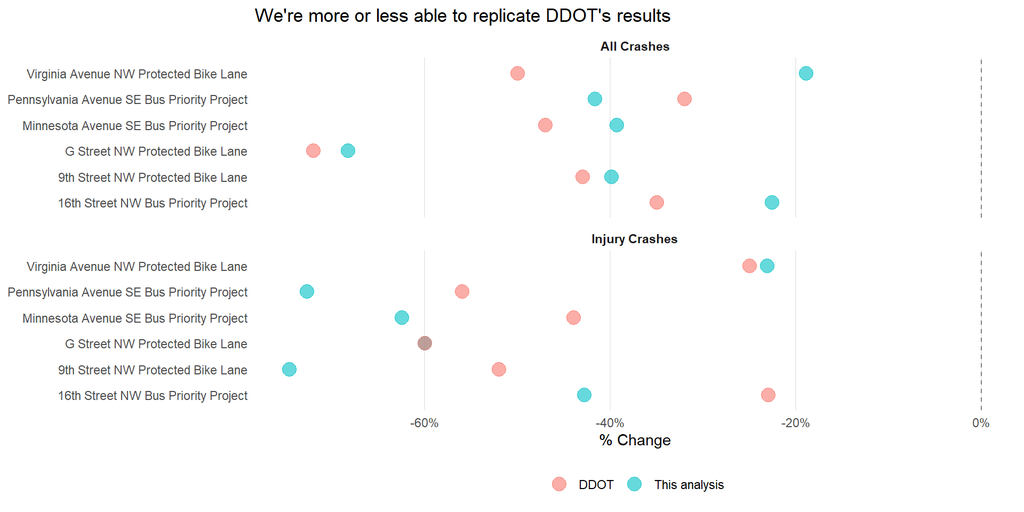

```r
eval_summary |>
  ggplot(aes(x = X..change, y = Project, color=Source)) +
  geom_vline(xintercept = 0, linetype = "dashed", color = "grey50", linewidth = 0.5) +
  geom_point(size = 4.5, alpha=.6) +
  facet_wrap(~ Outcome, ncol = 1, scales = "free_y") +
  scale_x_continuous(labels = scales::label_percent(scale = 1)) +
  labs(x = "% Change", y = NULL, color = "Outcome") +
  theme_minimal(base_size = 11) +
  theme(
    panel.grid.major.y = element_blank(),
    panel.grid.minor   = element_blank(),
    strip.text         = element_text(face = "bold"),
    legend.position    = "bottom",
    legend.title       = element_blank()
  ) +
  ggtitle("We're more or less able to replicate DDOT's results")
```

You can view detailed tables and time series by clicking the little arrows below. The line charts are smoothed, showing a 4 month moving average.

```r
for (myl in eval_objs) {
  cat("\n<details>\n<summary>", myl[[1]], "</summary>\n\n")
  print(myl[[2]])
  cat("\n")
  print(myl[[3]] %>%
          rename(Outcome = series, `% change` = pct_change, `DDOT % change` = pct_change_ddot,
                 `Pre (per month)` = Pre_per_month, `Post (per month)` = Post_per_month) %>% knitr::kable())
  cat("\n</details>\n")
}
```

**16th Street NW Bus Priority Project**

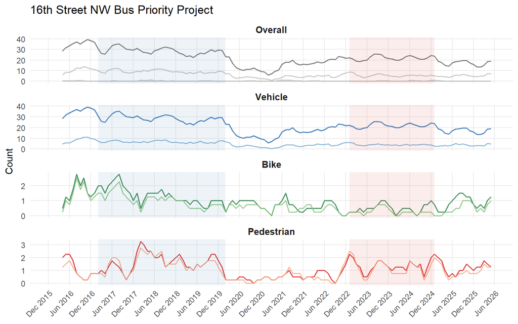

| Outcome | Pre (per month) | Post (per month) | % change | DDOT % change |
| --- | --- | --- | --- | --- |
| All Crashes | 28.58 | 22.12 | -22.6 | -35 |
| Injury Crashes | 9.25 | 5.29 | -42.8 | -23 |
| Serious Injury Crashes | 0.36 | 0.38 | 3.8 | NA |
| Fatal Crashes | 0.00 | 0.04 | Inf | NA |
| Vehicle Crashes | 28.50 | 22.12 | -22.4 | NA |
| Bike Crashes | 1.31 | 0.54 | -58.5 | -56 |
| Pedestrian Crashes | 1.61 | 1.38 | -14.7 | -20 |
| Driver Injury | 6.75 | 3.83 | -43.2 | NA |
| Bicyclist Injury | 1.00 | 0.29 | -70.8 | -71 |
| Pedestrian Injury | 1.50 | 1.17 | -22.2 | -13 |

**9th Street NW Protected Bike Lane**

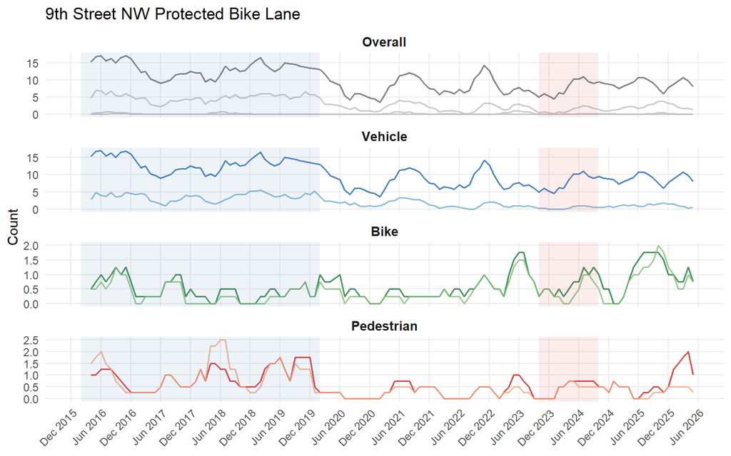

| Outcome | Pre (per month) | Post (per month) | % change | DDOT % change |
| --- | --- | --- | --- | --- |
| All Crashes | 13.17 | 7.92 | -39.9 | -43 |
| Injury Crashes | 4.92 | 1.25 | -74.6 | -52 |
| Serious Injury Crashes | 0.19 | 0.08 | -55.6 | NA |
| Fatal Crashes | 0.02 | 0.00 | -100.0 | NA |
| Vehicle Crashes | 13.15 | 7.92 | -39.8 | NA |
| Bike Crashes | 0.46 | 0.75 | 63.6 | -63 |
| Pedestrian Crashes | 0.88 | 0.50 | -42.9 | -50 |
| Driver Injury | 3.62 | 0.42 | -88.5 | NA |
| Bicyclist Injury | 0.33 | 0.42 | 25.0 | -77 |
| Pedestrian Injury | 0.96 | 0.42 | -56.5 | -56 |

**G Street NW Protected Bike Lane**

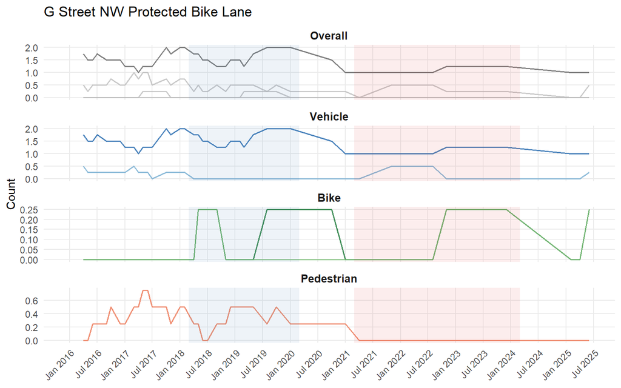

| Outcome | Pre (per month) | Post (per month) | % change | DDOT % change |
| --- | --- | --- | --- | --- |
| All Crashes | 0.88 | 0.28 | -68.3 | -72 |
| Injury Crashes | 0.21 | 0.08 | -60.0 | -60 |
| Serious Injury Crashes | 0.04 | 0.00 | -100.0 | NA |
| Fatal Crashes | 0.00 | 0.00 | NaN | NA |
| Vehicle Crashes | 0.88 | 0.28 | -68.3 | NA |
| Bike Crashes | 0.08 | 0.03 | -66.7 | NA |
| Pedestrian Crashes | 0.17 | 0.00 | -100.0 | -92 |
| Driver Injury | 0.00 | 0.06 | Inf | NA |
| Bicyclist Injury | 0.04 | 0.03 | -33.3 | NA |
| Pedestrian Injury | 0.17 | 0.00 | -100.0 | -86 |

**Minnesota Avenue SE Bus Priority Project**

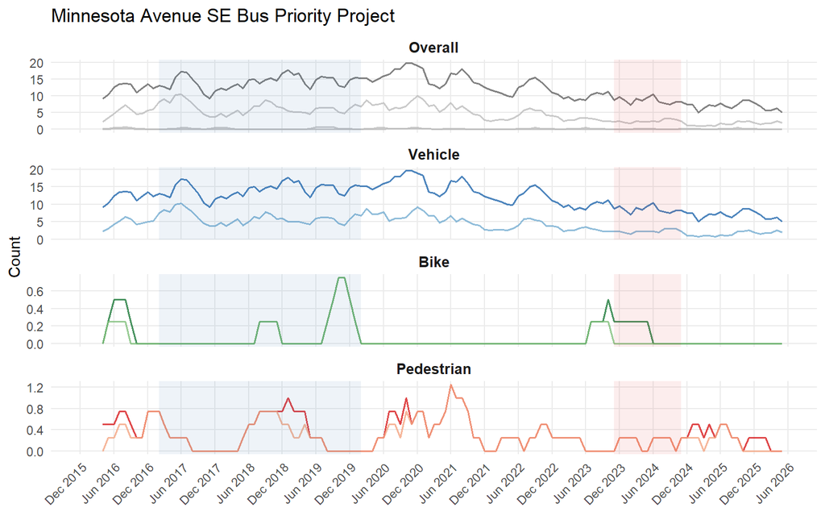

| Outcome | Pre (per month) | Post (per month) | % change | DDOT % change |
| --- | --- | --- | --- | --- |
| All Crashes | 14.28 | 8.67 | -39.3 | -47 |
| Injury Crashes | 6.44 | 2.42 | -62.5 | -44 |
| Serious Injury Crashes | 0.22 | 0.08 | -62.5 | NA |
| Fatal Crashes | 0.00 | 0.00 | NaN | NA |
| Vehicle Crashes | 14.28 | 8.58 | -39.9 | NA |
| Bike Crashes | 0.11 | 0.08 | -25.0 | -94 |
| Pedestrian Crashes | 0.28 | 0.17 | -40.0 | -40 |
| Driver Injury | 6.11 | 2.25 | -63.2 | NA |
| Bicyclist Injury | 0.11 | 0.00 | -100.0 | -100 |
| Pedestrian Injury | 0.22 | 0.17 | -25.0 | -18 |

**Pennsylvania Avenue SE Bus Priority Project**

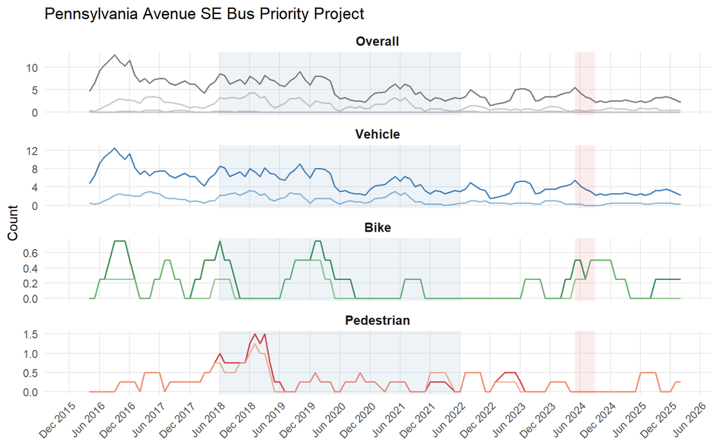

| Outcome | Pre (per month) | Post (per month) | % change | DDOT % change |
| --- | --- | --- | --- | --- |
| All Crashes | 5.15 | 3.0 | -41.7 | -32 |
| Injury Crashes | 1.83 | 0.5 | -72.7 | -56 |
| Serious Injury Crashes | 0.02 | 0.0 | -100.0 | NA |
| Fatal Crashes | 0.00 | 0.0 | NaN | NA |
| Vehicle Crashes | 5.12 | 3.0 | -41.5 | NA |
| Bike Crashes | 0.17 | 0.5 | 200.0 | NA |
| Pedestrian Crashes | 0.33 | 0.0 | -100.0 | -100 |
| Driver Injury | 1.44 | 0.0 | -100.0 | NA |
| Bicyclist Injury | 0.10 | 0.5 | 380.0 | NA |
| Pedestrian Injury | 0.29 | 0.0 | -100.0 | -100 |

**Virginia Avenue NW Protected Bike Lane**

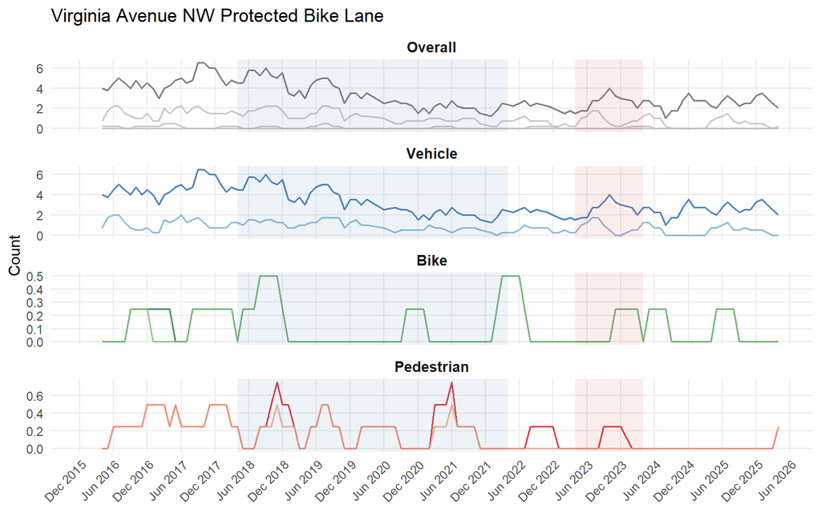

| Outcome | Pre (per month) | Post (per month) | % change | DDOT % change |
| --- | --- | --- | --- | --- |
| All Crashes | 2.98 | 2.42 | -18.9 | -50 |
| Injury Crashes | 1.08 | 0.83 | -23.1 | -25 |
| Serious Injury Crashes | 0.06 | 0.08 | 33.3 | NA |
| Fatal Crashes | 0.02 | 0.00 | -100.0 | NA |
| Vehicle Crashes | 2.98 | 2.42 | -18.9 | NA |
| Bike Crashes | 0.12 | 0.08 | -33.3 | NA |
| Pedestrian Crashes | 0.19 | 0.08 | -55.6 | -57 |
| Driver Injury | 0.81 | 0.75 | -7.7 | NA |
| Bicyclist Injury | 0.12 | 0.08 | -33.3 | NA |
| Pedestrian Injury | 0.15 | 0.00 | -100.0 | -100 |

## Using additional data to expand on DDOT project evaluations

DDOT has looked at a few projects in depth. But we can also use DC’s crash data to look at every (or almost every) protected and buffered bike lane in DDOT’s “bike lane” shapefile that was built in the late 2010s and early 2020s.

**Click here to read a little more about my methodology**

Quick methodology:

- Took the [“Bicycle Lanes” shape file](https://opendata.dc.gov/datasets/DCGIS::bicycle-lanes/about) from Open Data DC and subset it to just “protected”, “dual protected”, “buffered”, and “dual buffered” bike lanes. We don’t really care about painted bike lanes, since those don’t have super robust safety benefits.
- Unioned together all of the subblock segments in that data set by route and build year, since different pieces of some routes were built in different years. I hand-labeled when each piece of the bike lanes were installed by using satellite imagery and google street view (this was a pain). You can find my hand-labeled data set [here](https://felt.com/map/protected-and-buffered-bike-lanes-4U8sjcFHQFif4Pft9CCwicC?loc=38.92185,-76.98843,13.59z).
- Overlaid the crash data, and assigned any crash that’s within 4 meters of the roadway segment’s center line to the corridor (DDOT codes the crashes to the center line, rather than wherever the MPD officer poked at the map on their iPad).
- Finally, we just plot the number of crashes per month on each route, before and after the protected or buffered bike lane was installed. I’m only showing routes that have at least 8 subblock segments and were installed between 2017 and 2024. I’m also not showing the lanes we just looked at above!
- I’m using 2017 to 2019 as the “pre” years, unless the bike lane was installed in 2017, 18, or 19. In that case, I use 2016 up to the installation year as the “pre” years.
- I’m using 2024 and 2025 as the “post” years, unless the bike lane was installed in 2024. In that case, I use 2025 as the “post” year.

The blue shading in the time series below shows the “before” period. The red shading shows the “after” period. I ignore peak COVID years (2020-2023) when calculating the before/after change, since those years were atypical.

Here’s a quick map of the routes. Hover over each route to see the route name, the install year, and whether it’s coded as protected (1) or buffered (0) in the Open Data DC data.

```r
# which years to include in the analysis
ANALYSIS_YEARS = c(2016, 2017, 2018, 2019, 2024, 2025)
POST_YEARS     = c(2024, 2025)
# whether to analyze the data at the subblock level (SUBBLOCKKEY) or
# block level (BLOCKKEY):
ANALYSIS_LEVEL = "SUBBLOCKKEY"
# which treatment groups to include, options include
# switcher     : units that got PBLs between 2020 and 2023 inclusive
# never_taker  : units that never got PBLs
# late_taker   : units that got PBLs in 2024 or 2025
# always_taker : units that got PBLs before 2019
TREATMENT_GROUPS_TO_INCLUDE = c("switcher", "never_taker")
# whether to include buffered bike lanes as well or just fully protected bike lanes
PBLS_ONLY = FALSE
# a bbox for map plotting so we don't plot tons of data at once:
PLOT_BBOX = c(xmin = -77.020, ymin = 38.94, xmax = -77.010, ymax = 38.944)

# load data:
cd                <- load_crash_data()
pbl               <- load_pbl_data(PBLS_ONLY)
cabi_sf           <- load_cabi_data()[[1]]
annual_cabi_rides <- load_cabi_data()[[2]]
rs                <- load_subblocks()
mm_trips <- st_read("data/DC_RideReport_MM_Trips.geojson", quiet=T)
segment_lookup <-
  readr::read_csv(file = "data/trips_subblocks_matched.csv", show_col_types = F)

mm_trips_tbl <-
  mm_trips                               %>%
  st_drop_geometry()                     %>%
  mutate(
    mean_2019_trips  = (trips_2019_Q1 + trips_2019_Q2 + trips_2019_Q3 + trips_2019_Q4) / 4,
    mean_2024_trips  = (trips_2024_Q1 + trips_2024_Q2 + trips_2024_Q3 + trips_2024_Q4) / 4,
    mean_2025_trips  = (trips_2025_Q1 + trips_2025_Q2 + trips_2025_Q3 + trips_2025_Q4) / 4,
    mean_24_25_trips = (mean_2024_trips + mean_2025_trips) / 2
  )                                      %>%
  select(OBJECTID, starts_with("mean_")) %>%
  replace(is.na(.), 0)


pbl <- pbl |>
  mutate(
    ROUTENAME = if_else(ROUTENAME == "Ramp-36001642", "IRVING ST NW", ROUTENAME),
    ROUTENAME = if_else(ROUTENAME == "KENYON ST NW" , "IRVING ST NW", ROUTENAME),
    ROUTENAME = if_else(ROUTENAME == "IRVING ST NE" , "IRVING ST NW", ROUTENAME),
    ROUTENAME = if_else(ROUTENAME == "PARK PL NW"   , "5TH ST NW"   , ROUTENAME),
    )

pbl_unioned <- pbl                                     |>
  group_by(ROUTENAME, build_year)                      |>
  summarise(
    min_install = min(build_year, na.rm = TRUE),
    max_install = max(build_year, na.rm = TRUE),
    `Has some protected lane segments` = if_else(
      max(!is.na(BIKELANE_PROTECTED) + !is.na(BIKELANE_DUAL_PROTECTED)) == 1,
          1, 0),
    n_segments  = n(),
    .groups = "drop"
  )                                                    |>
  filter(n_segments >= 8)

bl_subblock_trips <-
  pbl                                                  |>
  group_by(ROUTENAME, build_year)                      |>
  mutate(
    min_install = min(build_year, na.rm = TRUE),
    max_install = max(build_year, na.rm = TRUE),
    `Has some protected lane segments` = if_else(
      max(!is.na(BIKELANE_PROTECTED) + !is.na(BIKELANE_DUAL_PROTECTED)) == 1,
          1, 0),
    n_segments  = n(),
    .groups = "drop"
  )                                                    |>
  ungroup()                                            |>
  filter(n_segments >= 8)                              |>
  select(SUBBLOCKKEY, build_year,
         max_install, ROUTENAME)                       |>
  mutate(route_unique_id =
           paste0(ROUTENAME, " (", max_install, ")"))  |>
  st_drop_geometry()                                   |>
  dplyr::left_join(segment_lookup, by="SUBBLOCKKEY")   |>
  dplyr::left_join(mm_trips_tbl, by = "OBJECTID")
```

```r
plot_leaflet(lines_sf = pbl_unioned,
             line_labels = c("ROUTENAME", "build_year", "Has some protected lane segments"))
```

[interactive chart not shown]

Note that the categorization of the bike lane types is a little unintuitive. The 17th St NW bike lane, for example, is classified as “buffered” not “protected,” which sounds less safe, but the actual bike lane is great:

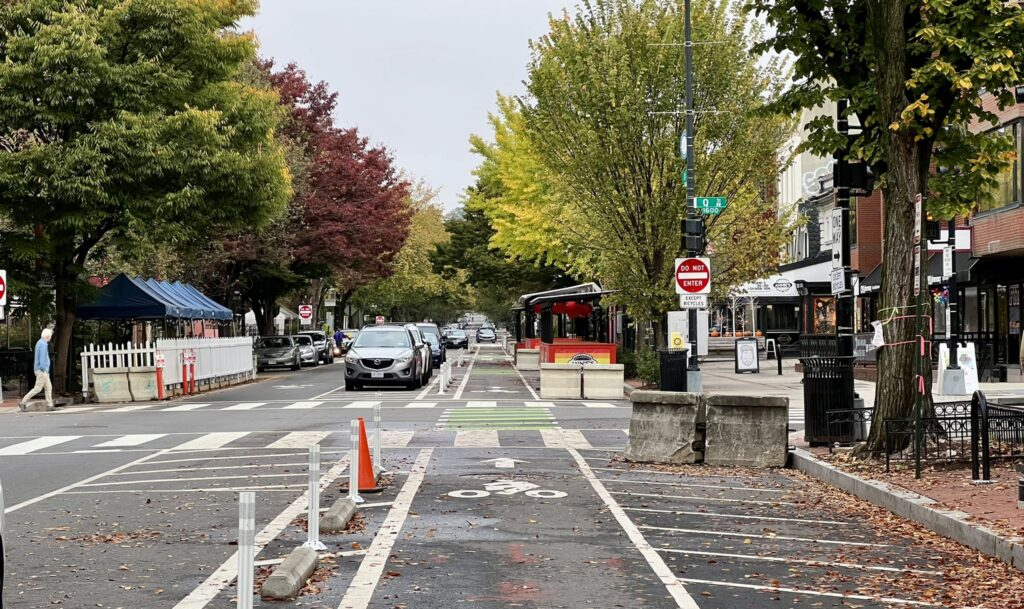

The 17th St NW bike lane.

(Photo by [Martha Wilson for PopVille](https://www.popville.com/2021/11/bike-lanes-dc-17th-street-nw/))

This bike lane was associated with some of the biggest safety improvements (see below).

High-level findings:

- Overall crashes, driver crashes, and people hitting pedestrians all almost universally go down, often by a lot.
- Bike crashes also often go down, but sometimes they go up. This is likely due to the fact that many more people are biking in those new bike lanes. Even an increase in the raw number of bike crashes in the corridor could mean an actual reduction in the number of crashes *per bike trip* if way more people are biking on that street because the new bike lane makes it safer.
- The specifics of the projects obviously matter. The 17th St NW street redesign made that street way safer. Contrast that with Mt Olivet Rd NE, which is still fairly wide (when you include the middle turn lane) and lacking in trees, both of which make drivers go faster.

```r
crashes_near_projects <- get_crashes_in_corridors(line_sf = pbl_unioned, crashes_sf = cd, buffer_in_meters = 4)
crashes_near_projects$route_unique_id <- paste0(crashes_near_projects$ROUTENAME, " (", crashes_near_projects$max_install, ")")


cd_in_projs_summed <-
  group_corridor_crashes_by_month(df = crashes_near_projects,
                                  group_by_vars = c("route_unique_id", "min_install", "max_install", "month", "year", "date", "Has some protected lane segments"),
                                  outcome_vars = outcome_vars)

already_shown <- c("21ST ST NW (2022)", "9TH ST NW (2023)", "G ST NW (2020)",  "MINNESOTA AVE SE (2023)", "PENNSYLVANIA AVE SE (2023)",  "VIRGINIA AVE NW (2022)")
```

```r
bl_summary <- data.frame("Project" = NA, "Outcome" = NA, "% change" = NA, "MM change" = NA, "Before" = NA, "After" = NA)
bl_objs    <- list()
for (proj in unique(cd_in_projs_summed$route_unique_id)) {

  temp_df <- filter(cd_in_projs_summed, year >= 2016 & route_unique_id == proj)

  temp_df$`Serious Injury Crashes` = temp_df$`Driver Serious Injury` + temp_df$`Pedestrian Serious Injury` + temp_df$`Bicyclist Serious Injury`

  proj_year <- unique(temp_df$min_install)
  if(proj_year < 2017) {next}
  # if (temp_df$route_unique_id[1] %in% already_shown) {next}

  if (proj_year < 2020) {
    p1sy = 2016; p1ey = proj_year - 1; p2sy = 2024; p2ey = 2025
  } else if (proj_year == 2024) {
    p1sy = 2017; p1ey = 2019; p2sy = 2025; p2ey = 2025
  } else {
    p1sy = 2017; p1ey = 2019; p2sy = 2024; p2ey = 2025
  }

  p1      <- list(label = "Pre" ,  start = paste0(p1sy, "-01-01"), end = paste0(p1ey, "-12-31"))
  p2      <- list(label = "Post",  start = paste0(p2sy, "-01-01"), end = paste0(p2ey, "-12-31"))

  rvs <- plot_crashes_over_time(
    data             = temp_df,
    smoothing_factor = 4,
    period_1         = p1,
    period_2         = p2,
    title            = proj
  )

  plot_table <-
    rvs[[3]] %>%
      rename(Outcome = series,
             `Before, per month` = Pre_per_month,
             `After, per month`  = Post_per_month,
             `% change`          = pct_change)

  mm_data <-
    filter(bl_subblock_trips, route_unique_id==proj)                     |>
    summarize(mean_2019_trips  = round(mean(mean_2019_trips , na.rm=T)),
              mean_24_25_trips = round(mean(mean_24_25_trips, na.rm=T))) |>
    mutate(mm_increase     = mean_24_25_trips - mean_2019_trips,
           mm_pct_increase = round(100*(mean_24_25_trips - mean_2019_trips) / mean_2019_trips))

  bl_objs <- c(bl_objs,
               list(list("project_name"=proj,
                         "plotly_chart"=rvs[[1]],
                         "table"=plot_table,
                         "mm_data" = mm_data
                         )
                    )
               )

  bl_summary <- bind_rows(
    bl_summary,
    data.frame("Project" = rep(proj, 4),
               "Outcome" = c("All Crashes", "Injury Crashes", "Serious Injury Crashes", "Fatal Crashes"),
               "% change" = c(plot_table$`% change`[plot_table$Outcome == "All Crashes"],
                              plot_table$`% change`[plot_table$Outcome == "Injury Crashes"],
                              plot_table$`% change`[plot_table$Outcome == "Serious Injury Crashes"],
                              plot_table$`% change`[plot_table$Outcome == "Fatal Crashes"]),
               "Before"   = c(plot_table$`Before, per month`[plot_table$Outcome == "All Crashes"],
                              plot_table$`Before, per month`[plot_table$Outcome == "Injury Crashes"],
                              plot_table$`Before, per month`[plot_table$Outcome == "Serious Injury Crashes"],
                              plot_table$`Before, per month`[plot_table$Outcome == "Fatal Crashes"]),
               "After"    = c(plot_table$`After, per month`[plot_table$Outcome == "All Crashes"],
                              plot_table$`After, per month`[plot_table$Outcome == "Injury Crashes"],
                              plot_table$`After, per month`[plot_table$Outcome == "Serious Injury Crashes"],
                              plot_table$`After, per month`[plot_table$Outcome == "Fatal Crashes"])
               )
  )
}


bl_summary <- bl_summary[!is.na(bl_summary$Outcome),]

to_show_1 <-
  bl_summary %>%
  group_by(Outcome) %>%
  summarise(
    before_per_year  = sum(Before, na.rm=T)*12,
    after_per_year   = sum(After, na.rm=T)*12,
    mean_pct_change       = mean(`X..change`, na.rm=T),
    pooled_pct_change = (after_per_year - before_per_year) / before_per_year
  )



before <- setNames(to_show_1$before_per_year, to_show_1$Outcome)
after  <- setNames(to_show_1$after_per_year,  to_show_1$Outcome)

to_show_2 <- tribble(
  ~Outcome,                     ~before_per_year,                                                  ~after_per_year,
  "Property Destruction Only",  before["All Crashes"] - before["Injury Crashes"] - before["Fatal Crashes"], after["All Crashes"] - after["Injury Crashes"] - after["Fatal Crashes"],
  "Fatal Crashes",              before["Fatal Crashes"],                                                after["Fatal Crashes"],
  "More Minor Injury Crashes",  before["Injury Crashes"] - before["Serious Injury Crashes"],             after["Injury Crashes"] - after["Serious Injury Crashes"],
  "Serious Injury Crashes",     before["Serious Injury Crashes"],                                        after["Serious Injury Crashes"]
)

to_show_1
```

```
## # A tibble: 4 × 5
##   Outcome       before_per_year after_per_year mean_pct_change pooled_pct_change
##   <chr>                   <dbl>          <dbl>           <dbl>             <dbl>
## 1 All Crashes            986.            590.            -43.2            -0.402
## 2 Fatal Crashes            1.44            0            -100              -1
## 3 Injury Crash…          395.            149.            -61.9            -0.623
## 4 Serious Inju…           19.0            10.3           -36.3            -0.456
```

```r
to_show_2 %>% mutate(reduction = after_per_year - before_per_year)
```

```
## # A tibble: 4 × 4
##   Outcome                   before_per_year after_per_year reduction
##   <chr>                               <dbl>          <dbl>     <dbl>
## 1 Property Destruction Only          590.            441     -149.
## 2 Fatal Crashes                        1.44            0       -1.44
## 3 More Minor Injury Crashes          376.            138.    -237.
## 4 Serious Injury Crashes              19.0            10.3     -8.64
```

```r
bl_summary <-
  bl_summary %>%
  select(-Before, -After) %>%
  filter((Outcome != "Serious Injury Crashes") & (Outcome != "Fatal Crashes")) %>%
  filter(!(Project %in% already_shown))
```

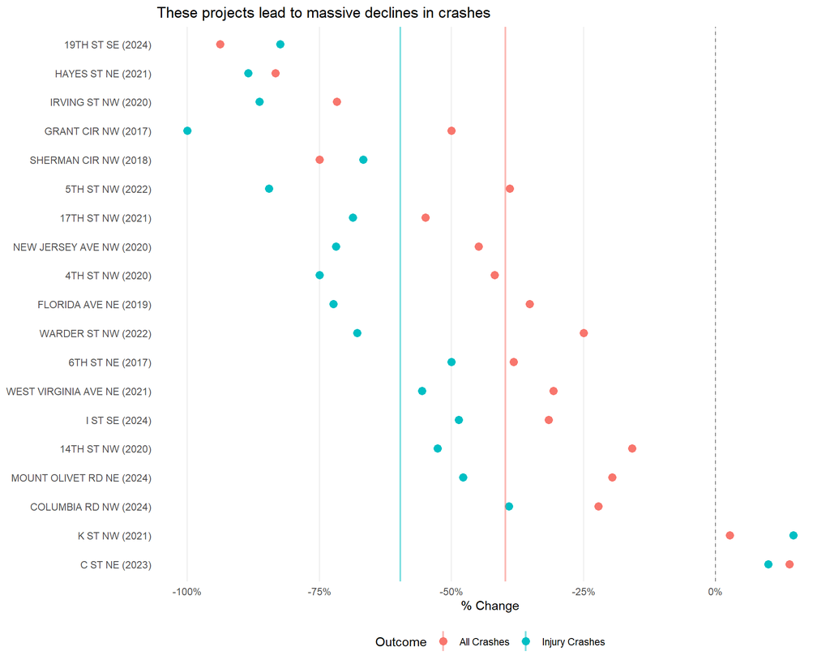

```r
bl_summary |>
  mutate(Project = reorder(Project, -X..change)) |>
  ggplot(aes(x = X..change, y = Project, color = Outcome)) +
  geom_vline(xintercept = 0, linetype = "dashed", color = "grey50", linewidth = 0.5) +
  geom_point(size = 3) +
  geom_vline(
    data = bl_summary    |>
      group_by(Outcome)  |>
      summarise(mean_change = mean(X..change, na.rm = TRUE), .groups = "drop"),
    aes(xintercept = mean_change, color = Outcome),
    linetype = "solid",
    linewidth = 0.8,
    alpha=.5
  ) +
  scale_x_continuous(labels = scales::label_percent(scale = 1)) +
  labs(x = "% Change", y = NULL, color = "Outcome") +
  theme_minimal(base_size = 11) +
  theme(
    panel.grid.major.y = element_blank(),
    panel.grid.minor   = element_blank(),
    strip.text         = element_text(face = "bold"),
    legend.position    = "bottom"
  ) +
  ggtitle("These projects lead to massive declines in crashes")
```

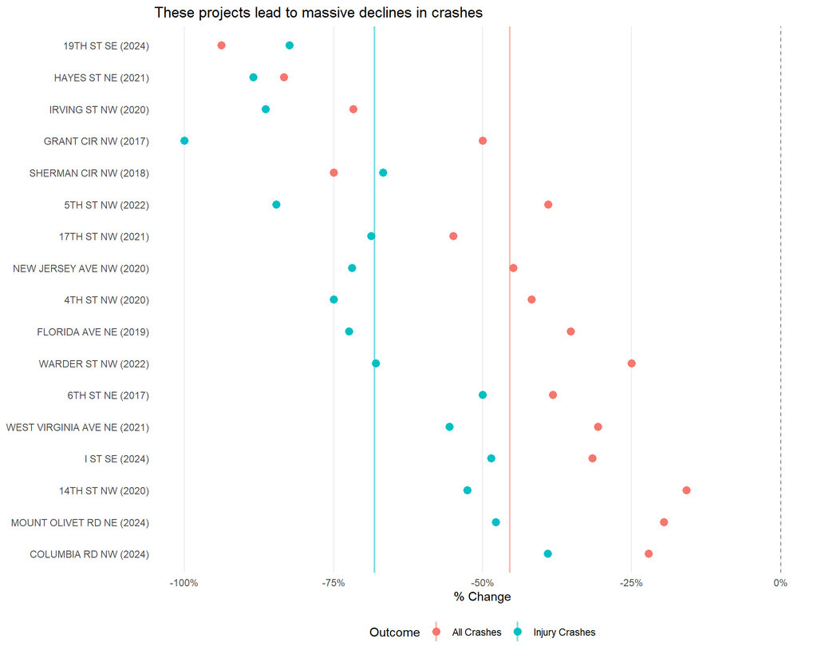

```r
bl_summary |>
  mutate(Project = reorder(Project, -X..change)) |>
  filter(!(Project %in% c("K ST NW (2021)", "C ST NE (2023)"))) |>
  ggplot(aes(x = X..change, y = Project, color = Outcome)) +
  geom_vline(xintercept = 0, linetype = "dashed", color = "grey50", linewidth = 0.5) +
  geom_point(size = 3) +
  geom_vline(
    data = bl_summary    |>
      filter(!(Project %in% c("K ST NW (2021)", "C ST NE (2023)"))) |>
      group_by(Outcome)  |>
      summarise(mean_change = mean(X..change, na.rm = TRUE), .groups = "drop"),
    aes(xintercept = mean_change, color = Outcome),
    linetype = "solid",
    linewidth = 0.8,
    alpha=.5
  ) +
  scale_x_continuous(labels = scales::label_percent(scale = 1)) +
  labs(x = "% Change", y = NULL, color = "Outcome") +
  theme_minimal(base_size = 11) +
  theme(
    panel.grid.major.y = element_blank(),
    panel.grid.minor   = element_blank(),
    strip.text         = element_text(face = "bold"),
    legend.position    = "bottom"
  ) +
  ggtitle("These projects lead to massive declines in crashes")
```

You can view detailed tables and time series by clicking the little arrows below. The line charts are smoothed, showing a 4 month moving average. Below the table, you can also see the change in “micromobility trips” (ebikes and scooters) from [RideReport.com](https://public.ridereport.com/dc?x=-77.0098713&y=38.9130548&z=10.91&time=2026-Q1).

```r
for (myl in bl_objs) {
  cat("<details>\n<summary>", myl$project_name, "</summary>")
  print(myl$plotly_chart)
  print(myl$table %>% knitr::kable())
  cat(paste0("<strong>Change in micromobility usage</strong><br>",
               "2019 micromobility trips: ", format(myl$mm_data$mean_2019_trips, big.mark = ",") , "<br>",
               "Avg. of '24 & '25 trips:  ", format(myl$mm_data$mean_24_25_trips, big.mark = ","), "<br>",
               "Increase in trips:        ", format(myl$mm_data$mm_increase, big.mark = ",")     ,  "<br>",
               "% increase:               ", format(myl$mm_data$mm_pct_increase, big.mark = ",") ,  "<br>"
               )
        )
  cat("\n\n</details>\n")
}
```

**14TH ST NW (2020)**

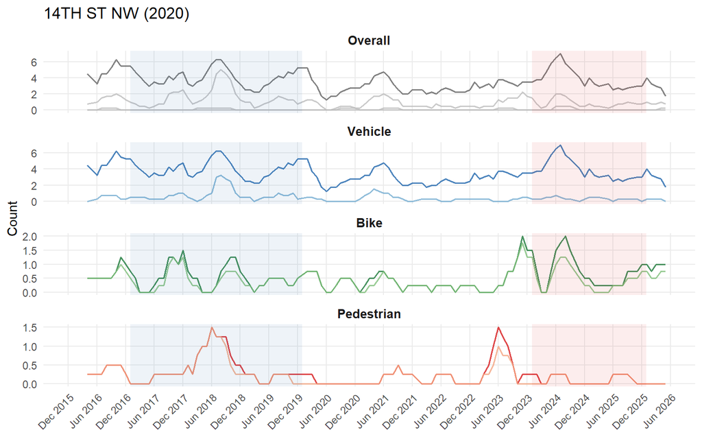

| Outcome | Before, per month | After, per month | % change |
| --- | --- | --- | --- |
| All Crashes | 4.06 | 3.42 | -15.8 |
| Injury Crashes | 1.58 | 0.75 | -52.6 |
| Serious Injury Crashes | 0.06 | 0.08 | 50.0 |
| Fatal Crashes | 0.00 | 0.00 | NaN |
| Vehicle Crashes | 4.06 | 3.42 | -15.8 |
| Bike Crashes | 0.53 | 0.62 | 18.4 |
| Pedestrian Crashes | 0.42 | 0.08 | -80.0 |
| Driver Injury | 0.81 | 0.25 | -69.0 |
| Bicyclist Injury | 0.42 | 0.42 | 0.0 |
| Pedestrian Injury | 0.36 | 0.08 | -76.9 |

**Change in micromobility usage**  
2019 micromobility trips: 586  
Avg. of ’24 & ’25 trips: 9,032  
Increase in trips: 8,446  
% increase: 1,441

**17TH ST NW (2021)**

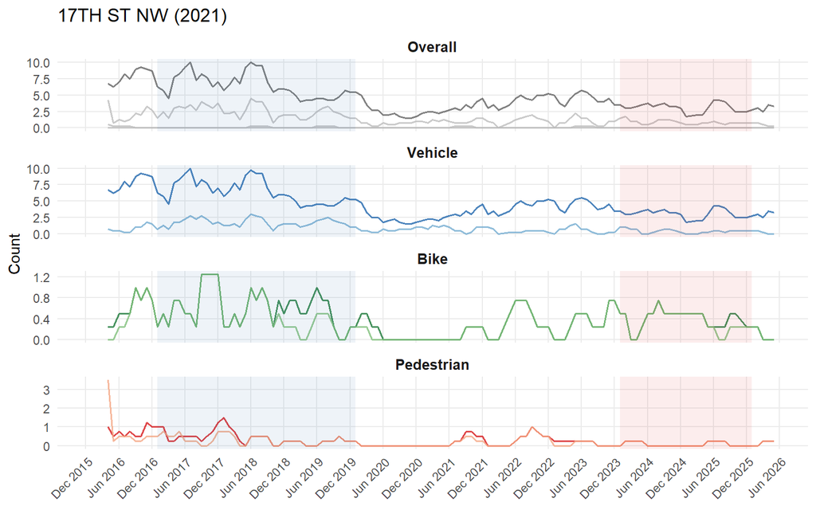

| Outcome | Before, per month | After, per month | % change |
| --- | --- | --- | --- |
| All Crashes | 6.47 | 2.92 | -54.9 |
| Injury Crashes | 2.53 | 0.79 | -68.7 |
| Serious Injury Crashes | 0.06 | 0.00 | -100.0 |
| Fatal Crashes | 0.00 | 0.00 | NaN |
| Vehicle Crashes | 6.42 | 2.92 | -54.5 |
| Bike Crashes | 0.61 | 0.33 | -45.5 |
| Pedestrian Crashes | 0.39 | 0.08 | -78.6 |
| Driver Injury | 1.72 | 0.42 | -75.8 |
| Bicyclist Injury | 0.50 | 0.29 | -41.7 |
| Pedestrian Injury | 0.31 | 0.08 | -72.7 |

**Change in micromobility usage**  
2019 micromobility trips: 366  
Avg. of ’24 & ’25 trips: 3,757  
Increase in trips: 3,391  
% increase: 927

**19TH ST SE (2024)**

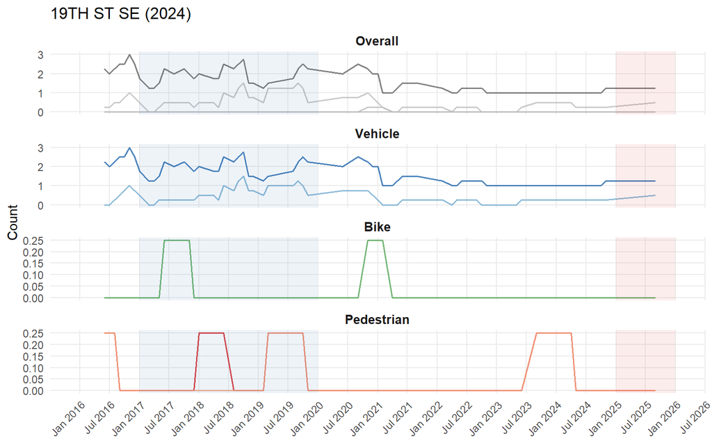

| Outcome | Before, per month | After, per month | % change |
| --- | --- | --- | --- |
| All Crashes | 1.33 | 0.08 | -93.8 |
| Injury Crashes | 0.47 | 0.08 | -82.4 |
| Serious Injury Crashes | 0.00 | 0.00 | NaN |
| Fatal Crashes | 0.00 | 0.00 | NaN |
| Vehicle Crashes | 1.33 | 0.08 | -93.8 |
| Bike Crashes | 0.03 | 0.00 | -100.0 |
| Pedestrian Crashes | 0.06 | 0.00 | -100.0 |
| Driver Injury | 0.42 | 0.08 | -80.0 |
| Bicyclist Injury | 0.03 | 0.00 | -100.0 |
| Pedestrian Injury | 0.03 | 0.00 | -100.0 |

**Change in micromobility usage**  
2019 micromobility trips: 12  
Avg. of ’24 & ’25 trips: 812  
Increase in trips: 800  
% increase: 6,667

**4TH ST NW (2020)**

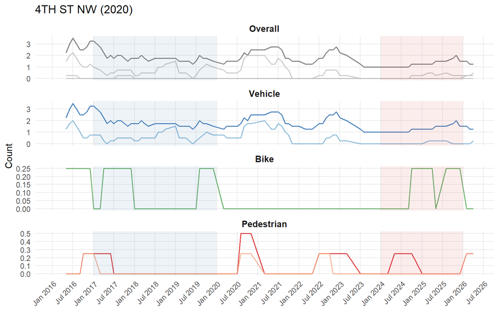

| Outcome | Before, per month | After, per month | % change |
| --- | --- | --- | --- |
| All Crashes | 1.36 | 0.79 | -41.8 |
| Injury Crashes | 0.50 | 0.12 | -75.0 |
| Serious Injury Crashes | 0.00 | 0.00 | NaN |
| Fatal Crashes | 0.03 | 0.00 | -100.0 |
| Vehicle Crashes | 1.36 | 0.79 | -41.8 |
| Bike Crashes | 0.08 | 0.08 | 0.0 |
| Pedestrian Crashes | 0.03 | 0.04 | 50.0 |
| Driver Injury | 0.42 | 0.04 | -90.0 |
| Bicyclist Injury | 0.08 | 0.08 | 0.0 |
| Pedestrian Injury | 0.00 | 0.00 | NaN |

**Change in micromobility usage**  
2019 micromobility trips: 118  
Avg. of ’24 & ’25 trips: 2,997  
Increase in trips: 2,879  
% increase: 2,440

**5TH ST NW (2022)**

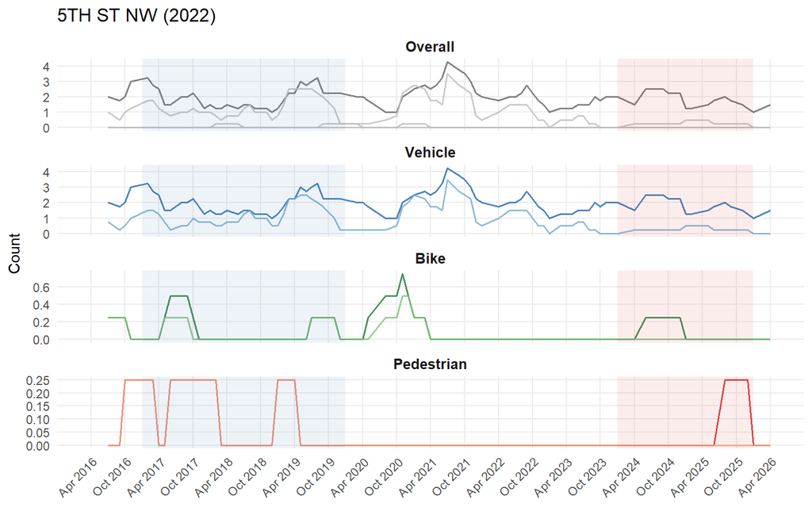

| Outcome | Before, per month | After, per month | % change |
| --- | --- | --- | --- |
| All Crashes | 1.64 | 1.00 | -39.0 |
| Injury Crashes | 1.08 | 0.17 | -84.6 |
| Serious Injury Crashes | 0.06 | 0.00 | -100.0 |
| Fatal Crashes | 0.00 | 0.00 | NaN |
| Vehicle Crashes | 1.64 | 1.00 | -39.0 |
| Bike Crashes | 0.08 | 0.04 | -50.0 |
| Pedestrian Crashes | 0.08 | 0.04 | -50.0 |
| Driver Injury | 0.94 | 0.17 | -82.4 |
| Bicyclist Injury | 0.06 | 0.00 | -100.0 |
| Pedestrian Injury | 0.08 | 0.00 | -100.0 |

**Change in micromobility usage**  
2019 micromobility trips: 2  
Avg. of ’24 & ’25 trips: 710  
Increase in trips: 708  
% increase: 35,400

**6TH ST NE (2017)**

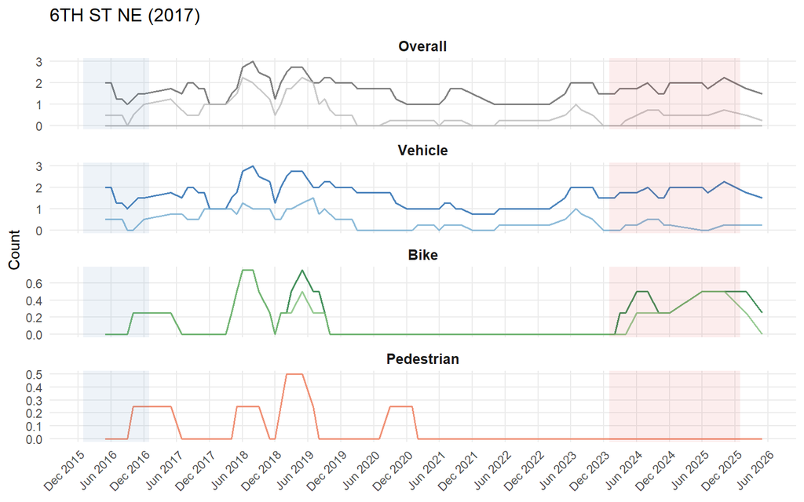

| Outcome | Before, per month | After, per month | % change |
| --- | --- | --- | --- |
| All Crashes | 1.42 | 0.88 | -38.2 |
| Injury Crashes | 0.50 | 0.25 | -50.0 |
| Serious Injury Crashes | 0.00 | 0.00 | NaN |
| Fatal Crashes | 0.00 | 0.00 | NaN |
| Vehicle Crashes | 1.42 | 0.88 | -38.2 |
| Bike Crashes | 0.08 | 0.17 | 100.0 |
| Pedestrian Crashes | 0.08 | 0.00 | -100.0 |
| Driver Injury | 0.33 | 0.12 | -62.5 |
| Bicyclist Injury | 0.08 | 0.12 | 50.0 |
| Pedestrian Injury | 0.08 | 0.00 | -100.0 |

**Change in micromobility usage**  
2019 micromobility trips: 42  
Avg. of ’24 & ’25 trips: 3,143  
Increase in trips: 3,101  
% increase: 7,383

**9TH ST NW (2023)**

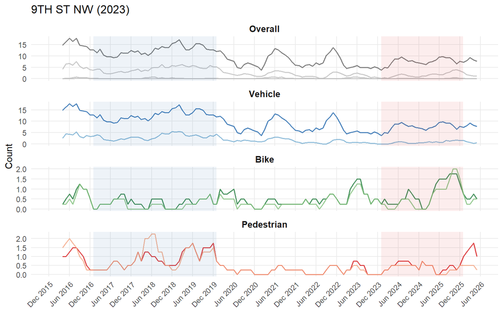

| Outcome | Before, per month | After, per month | % change |
| --- | --- | --- | --- |
| All Crashes | 12.58 | 7.83 | -37.7 |
| Injury Crashes | 4.33 | 1.88 | -56.7 |
| Serious Injury Crashes | 0.17 | 0.17 | 0.0 |
| Fatal Crashes | 0.00 | 0.00 | NaN |
| Vehicle Crashes | 12.58 | 7.79 | -38.1 |
| Bike Crashes | 0.33 | 0.79 | 137.5 |
| Pedestrian Crashes | 0.89 | 0.46 | -48.4 |
| Driver Injury | 3.14 | 0.88 | -72.1 |
| Bicyclist Injury | 0.22 | 0.62 | 181.3 |
| Pedestrian Injury | 0.97 | 0.38 | -61.4 |

**Change in micromobility usage**  
2019 micromobility trips: 850  
Avg. of ’24 & ’25 trips: 10,270  
Increase in trips: 9,420  
% increase: 1,108

**C ST NE (2023)**

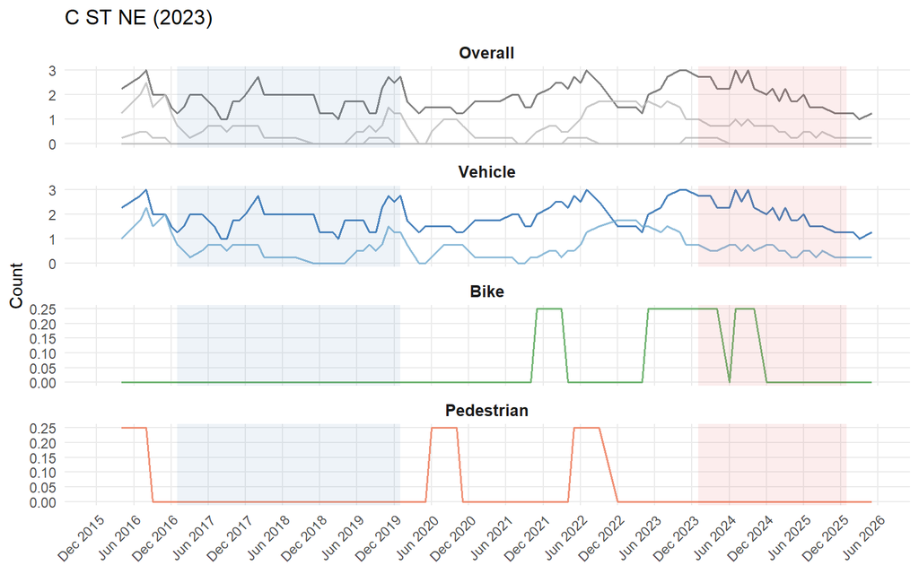

| Outcome | Before, per month | After, per month | % change |
| --- | --- | --- | --- |
| All Crashes | 1.39 | 1.58 | 14 |
| Injury Crashes | 0.42 | 0.46 | 10 |
| Serious Injury Crashes | 0.03 | 0.00 | -100 |
| Fatal Crashes | 0.00 | 0.00 | NaN |
| Vehicle Crashes | 1.39 | 1.58 | 14 |
| Bike Crashes | 0.00 | 0.04 | Inf |
| Pedestrian Crashes | 0.00 | 0.00 | NaN |
| Driver Injury | 0.42 | 0.42 | 0 |
| Bicyclist Injury | 0.00 | 0.04 | Inf |
| Pedestrian Injury | 0.00 | 0.00 | NaN |

**Change in micromobility usage**  
2019 micromobility trips: 0  
Avg. of ’24 & ’25 trips: 1,139  
Increase in trips: 1,139  
% increase: Inf

**COLUMBIA RD NW (2024)**

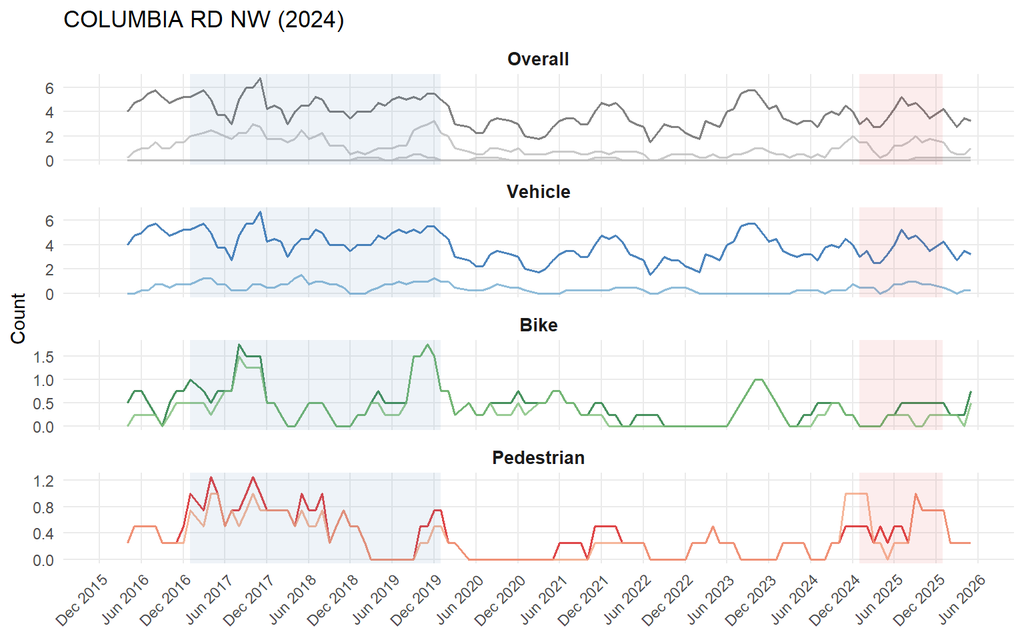

| Outcome | Before, per month | After, per month | % change |
| --- | --- | --- | --- |
| All Crashes | 4.50 | 3.50 | -22.2 |
| Injury Crashes | 1.78 | 1.08 | -39.1 |
| Serious Injury Crashes | 0.08 | 0.08 | 0.0 |
| Fatal Crashes | 0.00 | 0.00 | NaN |
| Vehicle Crashes | 4.47 | 3.42 | -23.6 |
| Bike Crashes | 0.67 | 0.33 | -50.0 |
| Pedestrian Crashes | 0.58 | 0.50 | -14.3 |
| Driver Injury | 0.69 | 0.50 | -28.0 |
| Bicyclist Injury | 0.58 | 0.17 | -71.4 |
| Pedestrian Injury | 0.50 | 0.42 | -16.7 |

**Change in micromobility usage**  
2019 micromobility trips: 247  
Avg. of ’24 & ’25 trips: 4,301  
Increase in trips: 4,054  
% increase: 1,641

**FLORIDA AVE NE (2019)**

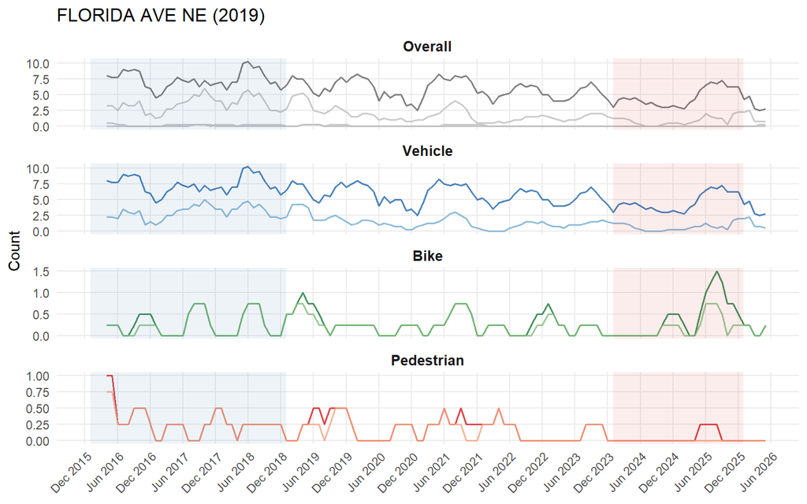

| Outcome | Before, per month | After, per month | % change |
| --- | --- | --- | --- |
| All Crashes | 7.33 | 4.75 | -35.2 |
| Injury Crashes | 3.47 | 0.96 | -72.4 |
| Serious Injury Crashes | 0.19 | 0.00 | -100.0 |
| Fatal Crashes | 0.03 | 0.00 | -100.0 |
| Vehicle Crashes | 7.33 | 4.75 | -35.2 |
| Bike Crashes | 0.25 | 0.42 | 66.7 |
| Pedestrian Crashes | 0.31 | 0.04 | -86.4 |
| Driver Injury | 2.97 | 0.75 | -74.8 |
| Bicyclist Injury | 0.22 | 0.21 | -6.2 |
| Pedestrian Injury | 0.28 | 0.00 | -100.0 |

**Change in micromobility usage**  
2019 micromobility trips: 234  
Avg. of ’24 & ’25 trips: 8,906  
Increase in trips: 8,672  
% increase: 3,706

**G ST NW (2020)**

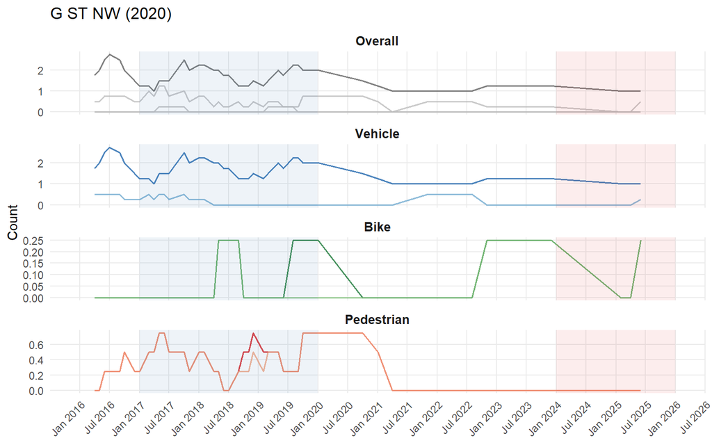

| Outcome | Before, per month | After, per month | % change |
| --- | --- | --- | --- |
| All Crashes | 1.22 | 0.12 | -89.8 |
| Injury Crashes | 0.42 | 0.08 | -80.0 |
| Serious Injury Crashes | 0.06 | 0.00 | -100.0 |
| Fatal Crashes | 0.00 | 0.00 | NaN |
| Vehicle Crashes | 1.22 | 0.12 | -89.8 |
| Bike Crashes | 0.06 | 0.04 | -25.0 |
| Pedestrian Crashes | 0.33 | 0.00 | -100.0 |
| Driver Injury | 0.08 | 0.04 | -50.0 |
| Bicyclist Injury | 0.03 | 0.04 | 50.0 |
| Pedestrian Injury | 0.31 | 0.00 | -100.0 |

**Change in micromobility usage**  
2019 micromobility trips: 362  
Avg. of ’24 & ’25 trips: 2,910  
Increase in trips: 2,548  
% increase: 704

**GRANT CIR NW (2017)**

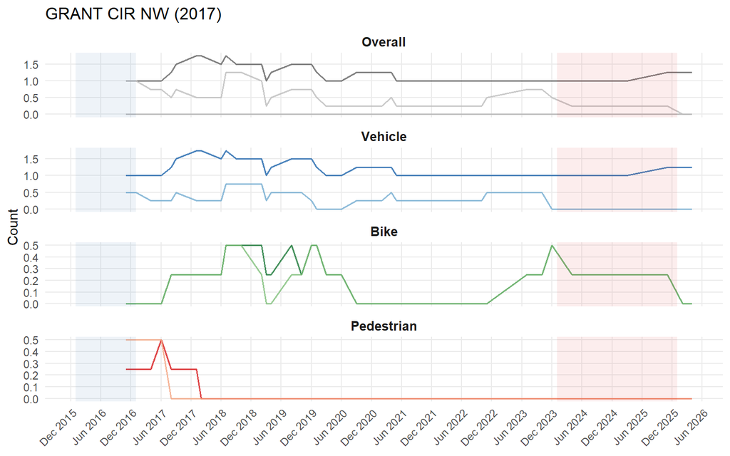

| Outcome | Before, per month | After, per month | % change |
| --- | --- | --- | --- |
| All Crashes | 0.33 | 0.17 | -50 |
| Injury Crashes | 0.33 | 0.00 | -100 |
| Serious Injury Crashes | 0.00 | 0.00 | NaN |
| Fatal Crashes | 0.00 | 0.00 | NaN |
| Vehicle Crashes | 0.33 | 0.17 | -50 |
| Bike Crashes | 0.00 | 0.00 | NaN |
| Pedestrian Crashes | 0.08 | 0.00 | -100 |
| Driver Injury | 0.17 | 0.00 | -100 |
| Bicyclist Injury | 0.00 | 0.00 | NaN |
| Pedestrian Injury | 0.17 | 0.00 | -100 |

**Change in micromobility usage**  
2019 micromobility trips: 0  
Avg. of ’24 & ’25 trips: 759  
Increase in trips: 759  
% increase: Inf

**HAYES ST NE (2021)**

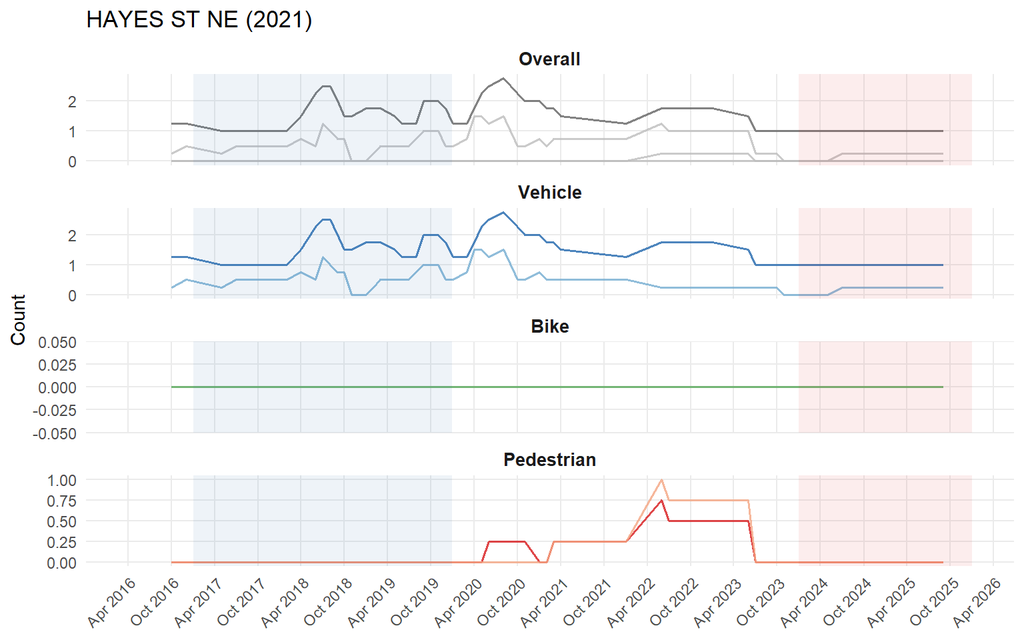

| Outcome | Before, per month | After, per month | % change |
| --- | --- | --- | --- |
| All Crashes | 1.00 | 0.17 | -83.3 |
| Injury Crashes | 0.36 | 0.04 | -88.5 |
| Serious Injury Crashes | 0.00 | 0.00 | NaN |
| Fatal Crashes | 0.00 | 0.00 | NaN |
| Vehicle Crashes | 1.00 | 0.17 | -83.3 |
| Bike Crashes | 0.00 | 0.00 | NaN |
| Pedestrian Crashes | 0.00 | 0.00 | NaN |
| Driver Injury | 0.36 | 0.04 | -88.5 |
| Bicyclist Injury | 0.00 | 0.00 | NaN |
| Pedestrian Injury | 0.00 | 0.00 | NaN |

**Change in micromobility usage**  
2019 micromobility trips: 0  
Avg. of ’24 & ’25 trips: 23  
Increase in trips: 23  
% increase: Inf

**I ST SE (2024)**

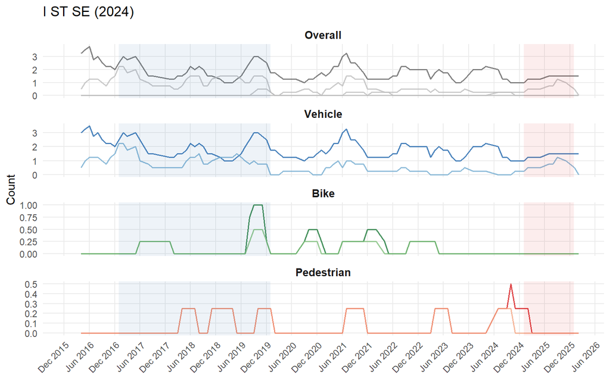

| Outcome | Before, per month | After, per month | % change |
| --- | --- | --- | --- |
| All Crashes | 1.58 | 1.08 | -31.6 |
| Injury Crashes | 0.97 | 0.50 | -48.6 |
| Serious Injury Crashes | 0.06 | 0.00 | -100.0 |
| Fatal Crashes | 0.00 | 0.00 | NaN |
| Vehicle Crashes | 1.58 | 1.08 | -31.6 |
| Bike Crashes | 0.14 | 0.00 | -100.0 |
| Pedestrian Crashes | 0.08 | 0.00 | -100.0 |
| Driver Injury | 0.81 | 0.50 | -37.9 |
| Bicyclist Injury | 0.08 | 0.00 | -100.0 |
| Pedestrian Injury | 0.08 | 0.00 | -100.0 |

**Change in micromobility usage**  
2019 micromobility trips: 114  
Avg. of ’24 & ’25 trips: 2,451  
Increase in trips: 2,337  
% increase: 2,050

**IRVING ST NW (2020)**

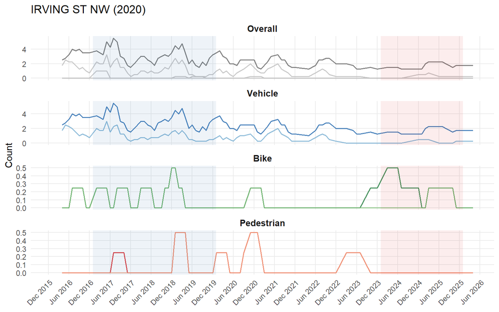

| Outcome | Before, per month | After, per month | % change |
| --- | --- | --- | --- |
| All Crashes | 2.94 | 0.83 | -71.7 |
| Injury Crashes | 1.22 | 0.17 | -86.4 |
| Serious Injury Crashes | 0.14 | 0.00 | -100.0 |
| Fatal Crashes | 0.03 | 0.00 | -100.0 |
| Vehicle Crashes | 2.94 | 0.83 | -71.7 |
| Bike Crashes | 0.14 | 0.08 | -40.0 |
| Pedestrian Crashes | 0.08 | 0.00 | -100.0 |
| Driver Injury | 1.03 | 0.12 | -87.8 |
| Bicyclist Injury | 0.14 | 0.04 | -70.0 |
| Pedestrian Injury | 0.06 | 0.00 | -100.0 |

**Change in micromobility usage**  
2019 micromobility trips: 65  
Avg. of ’24 & ’25 trips: 2,602  
Increase in trips: 2,537  
% increase: 3,903

**K ST NW (2021)**

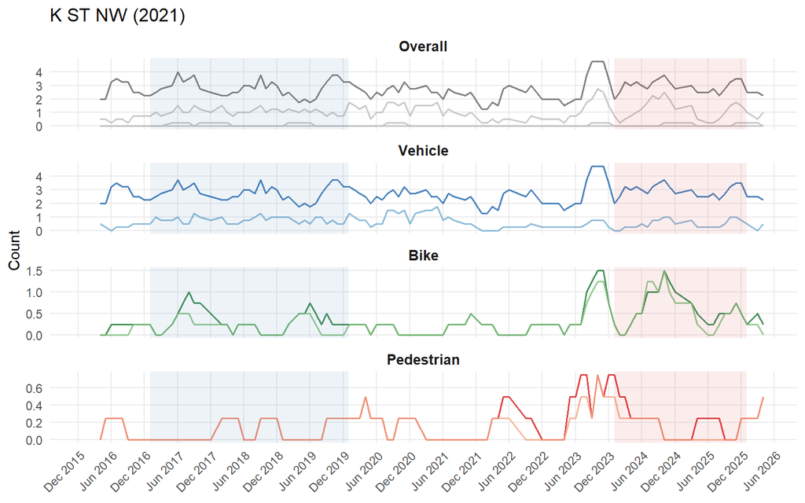

| Outcome | Before, per month | After, per month | % change |
| --- | --- | --- | --- |
| All Crashes | 2.56 | 2.62 | 2.7 |
| Injury Crashes | 0.94 | 1.08 | 14.7 |
| Serious Injury Crashes | 0.08 | 0.08 | 0.0 |
| Fatal Crashes | 0.00 | 0.00 | NaN |
| Vehicle Crashes | 2.53 | 2.62 | 3.8 |
| Bike Crashes | 0.28 | 0.54 | 95.0 |
| Pedestrian Crashes | 0.08 | 0.17 | 100.0 |
| Driver Injury | 0.69 | 0.46 | -34.0 |
| Bicyclist Injury | 0.17 | 0.50 | 200.0 |
| Pedestrian Injury | 0.08 | 0.12 | 50.0 |

**Change in micromobility usage**  
2019 micromobility trips: 369  
Avg. of ’24 & ’25 trips: 4,293  
Increase in trips: 3,924  
% increase: 1,063

**MINNESOTA AVE SE (2023)**

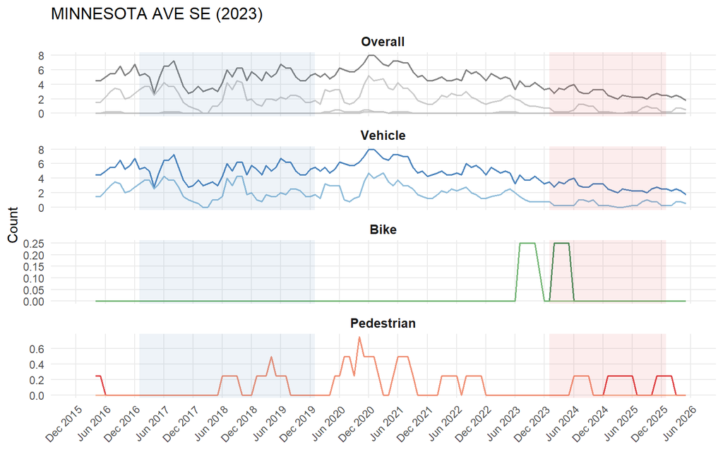

| Outcome | Before, per month | After, per month | % change |
| --- | --- | --- | --- |
| All Crashes | 4.86 | 2.50 | -48.6 |
| Injury Crashes | 2.14 | 0.46 | -78.6 |
| Serious Injury Crashes | 0.03 | 0.00 | -100.0 |
| Fatal Crashes | 0.00 | 0.00 | NaN |
| Vehicle Crashes | 4.86 | 2.50 | -48.6 |
| Bike Crashes | 0.00 | 0.04 | Inf |
| Pedestrian Crashes | 0.08 | 0.12 | 50.0 |
| Driver Injury | 2.06 | 0.42 | -79.7 |
| Bicyclist Injury | 0.00 | 0.00 | NaN |
| Pedestrian Injury | 0.08 | 0.04 | -50.0 |

**Change in micromobility usage**  
2019 micromobility trips: 5  
Avg. of ’24 & ’25 trips: 985  
Increase in trips: 980  
% increase: 19,600

**MOUNT OLIVET RD NE (2024)**

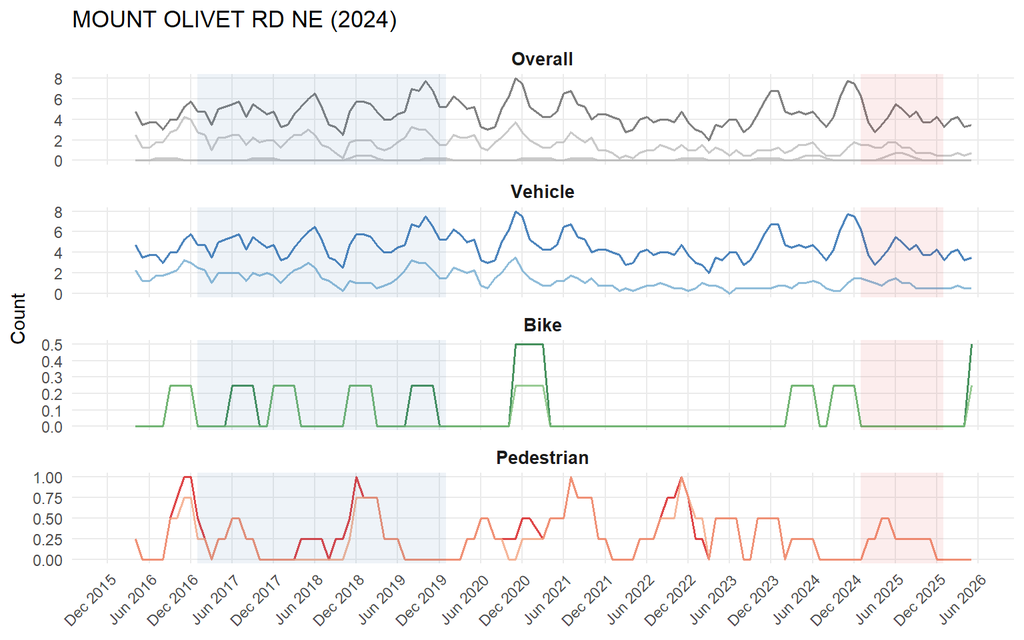

| Outcome | Before, per month | After, per month | % change |
| --- | --- | --- | --- |
| All Crashes | 4.97 | 4.00 | -19.6 |
| Injury Crashes | 1.92 | 1.00 | -47.8 |
| Serious Injury Crashes | 0.08 | 0.25 | 200.0 |
| Fatal Crashes | 0.03 | 0.00 | -100.0 |
| Vehicle Crashes | 4.94 | 4.00 | -19.1 |
| Bike Crashes | 0.11 | 0.00 | -100.0 |
| Pedestrian Crashes | 0.22 | 0.25 | 12.5 |
| Driver Injury | 1.69 | 0.75 | -55.7 |
| Bicyclist Injury | 0.06 | 0.00 | -100.0 |
| Pedestrian Injury | 0.17 | 0.25 | 50.0 |

**Change in micromobility usage**  
2019 micromobility trips: 10  
Avg. of ’24 & ’25 trips: 2,631  
Increase in trips: 2,621  
% increase: 26,210